# GSBS544 Lab 8

Author

Sahil Bains

Github Link: https://github.com/sbains2/GSBS544

Instructions You will submit an HTML document to Canvas as your final version.

Your document should show your code chunks/cells as well as any output. Make sure that only relevant output is printed. Do not, for example, print the entire dataset in your final rendered file.

Your document should also be clearly organized, so that it is easy for a reader to find your answers to each question.

The Data This week, we consider a dataset generated from text data.

The original dataset can be found here: https://www.kaggle.com/datasets/kingburrito666/cannabis-strains. It consists of user reviews of different strains of cannabis. Users rated their experience with the cannabis strain on a scale of 1 to 5. They also selected words from a long list to describe the Effects and the Flavor of the cannabis.

In the dataset linked above, each row is one strain of cannabis. The average rating of all testers is reported, as well as the most commonly used words for the effect and flavor.

Some data cleaning has been performed for you: The Effect and Flavor columns have been converted to dummy variables indicating if the particular word was used for the particular strain.

This cleaned data can be found at: https://www.dropbox.com/s/s2a1uoiegitupjc/cannabis_full.csv

Our goal will be to fit models that identify the Sativa types from the Indica types, and then to fit models that also distinguish the Hybrid types.

IMPORTANT: In this assignment, you do not need to consider different feature sets. Normally, this would be a good thing to try - but for this homework, simply include all the predictors for every model.

```bash
pip install plotnine
```

```python
import os
os.environ.pop("QUARTO_EXECUTE_INFO", None)
```

```
'/var/folders/ky/q2g7htq53933q1sz4qt6rvjm0000gn/T/quarto-sessiond52ef41782c2771e/9aa0deec0d1dac34/79195a22544a6382'
```

```python
# Importing all necessary libraries
import pandas as pd
import numpy as np
import pandas as pd
from sklearn.model_selection import train_test_split, cross_val_score, GridSearchCV
from sklearn.compose import ColumnTransformer
from sklearn.preprocessing import StandardScaler, OneHotEncoder
from sklearn.pipeline import Pipeline
from sklearn.linear_model import LogisticRegression
from sklearn.discriminant_analysis import LinearDiscriminantAnalysis, QuadraticDiscriminantAnalysis
from sklearn.neighbors import KNeighborsClassifier
from sklearn.svm import SVC
from sklearn.tree import DecisionTreeClassifier, plot_tree
from sklearn.metrics import accuracy_score, confusion_matrix, classification_report
from plotnine import *
import matplotlib.pyplot as plt
```

```python
# Reading in the data
df = pd.read_csv('weed.csv')
# Dropping NaNs
weed = df.dropna()
weed.info()
weed.describe()
```

```
<class 'pandas.core.frame.DataFrame'>
Index: 2191 entries, 0 to 2350
Data columns (total 69 columns):
 #   Column        Non-Null Count  Dtype
---  ------        --------------  -----
 0   Strain        2191 non-null   object
 1   Type          2191 non-null   object
 2   Rating        2191 non-null   float64
 3   Effects       2191 non-null   object
 4   Flavor        2191 non-null   object
 5   Creative      2191 non-null   float64
 6   Energetic     2191 non-null   float64
 7   Tingly        2191 non-null   float64
 8   Euphoric      2191 non-null   float64
 9   Relaxed       2191 non-null   float64
```

[output cut: 61 more lines]

|  | Rating | Creative | Energetic | Tingly | Euphoric | Relaxed | Aroused | Happy | Uplifted | Hungry | ... | Ammonia | Minty | Tree | Fruit | Butter | Pineapple | Tar | Rose | Plum | Pear |
| --- | --- | --- | --- | --- | --- | --- | --- | --- | --- | --- | --- | --- | --- | --- | --- | --- | --- | --- | --- | --- | --- |
| count | 2191.000000 | 2191.000000 | 2191.000000 | 2191.000000 | 2191.000000 | 2191.000000 | 2191.000000 | 2191.000000 | 2191.000000 | 2191.000000 | ... | 2191.000000 | 2191.000000 | 2191.000000 | 2191.000000 | 2191.000000 | 2191.000000 | 2191.000000 | 2191.000000 | 2191.000000 | 2191.000000 |
| mean | 4.430169 | 0.329986 | 0.283432 | 0.151073 | 0.727522 | 0.772250 | 0.088088 | 0.835691 | 0.670927 | 0.208581 | ... | 0.012780 | 0.018713 | 0.015518 | 0.015518 | 0.008672 | 0.019169 | 0.003651 | 0.007303 | 0.000913 | 0.001369 |
| std | 0.419576 | 0.470315 | 0.450767 | 0.358201 | 0.445336 | 0.419476 | 0.283487 | 0.370640 | 0.469984 | 0.406387 | ... | 0.112348 | 0.135540 | 0.123629 | 0.123629 | 0.092739 | 0.137151 | 0.060329 | 0.085162 | 0.030206 | 0.036986 |
| min | 0.000000 | 0.000000 | 0.000000 | 0.000000 | 0.000000 | 0.000000 | 0.000000 | 0.000000 | 0.000000 | 0.000000 | ... | 0.000000 | 0.000000 | 0.000000 | 0.000000 | 0.000000 | 0.000000 | 0.000000 | 0.000000 | 0.000000 | 0.000000 |
| 25% | 4.300000 | 0.000000 | 0.000000 | 0.000000 | 0.000000 | 1.000000 | 0.000000 | 1.000000 | 0.000000 | 0.000000 | ... | 0.000000 | 0.000000 | 0.000000 | 0.000000 | 0.000000 | 0.000000 | 0.000000 | 0.000000 | 0.000000 | 0.000000 |
| 50% | 4.400000 | 0.000000 | 0.000000 | 0.000000 | 1.000000 | 1.000000 | 0.000000 | 1.000000 | 1.000000 | 0.000000 | ... | 0.000000 | 0.000000 | 0.000000 | 0.000000 | 0.000000 | 0.000000 | 0.000000 | 0.000000 | 0.000000 | 0.000000 |
| 75% | 4.600000 | 1.000000 | 1.000000 | 0.000000 | 1.000000 | 1.000000 | 0.000000 | 1.000000 | 1.000000 | 0.000000 | ... | 0.000000 | 0.000000 | 0.000000 | 0.000000 | 0.000000 | 0.000000 | 0.000000 | 0.000000 | 0.000000 | 0.000000 |
| max | 5.000000 | 1.000000 | 1.000000 | 1.000000 | 1.000000 | 1.000000 | 1.000000 | 1.000000 | 1.000000 | 1.000000 | ... | 1.000000 | 1.000000 | 1.000000 | 1.000000 | 1.000000 | 1.000000 | 1.000000 | 1.000000 | 1.000000 | 1.000000 |

8 rows × 65 columns

Part One: Binary Classification Create a dataset that is limited only to the Sativa and Indica type cannabis strains.

This section asks you to create a final best model for each of the four new model types studied this week: LDA, QDA, SVC, and SVM. For SVM, you may limit yourself to only the polynomial kernel.

For each, you should:

Choose a metric you will use to select your model, and briefly justify your choice. (Hint: There is no specific target category here, so this should not be a metric that only prioritizes one category.)

Find the best model for predicting the Type variable. Don’t forget to tune any hyperparameters.

Report the (cross-validated!) metric.

Fit the final model.

Output a confusion matrix.

Q1: LDA Q2: QDA Q3: SVC Q4: SVM

Creating a dataset with targets Indica and Sativa

```python
# Subsetting the dataset with limiting targets to Indica and Sativa
weed = weed[(weed['Type'] == 'indica') | (weed['Type'] == 'sativa')]

# Checking that there are only two types in the Type column
weed['Type'].nunique()
```

```
2
```

Basic model setup

```python
# Creating target and explanatory variables
X = weed.drop(columns=['Type'])
y = weed['Type']

# Getting numeric and categorical variables
num = X.select_dtypes(include=['number']).columns
cat = X.select_dtypes(exclude=['number']).columns

# Defining columnTransformer for preprocessing steps
ct = ColumnTransformer(
    transformers=[
    ('num', StandardScaler(), num),
    ('cat', OneHotEncoder(handle_unknown='ignore', sparse_output=False), cat)
])

# Doing a test-train split to partition training and testing data
Xt, Xv, yt, yv = train_test_split(X, y, test_size=0.2, random_state=42)
```

In this section, I use overall accuracy as the scoring metric. Since there’s no ‘positive’ class, accuracy is appropriate as it weighs the errors for both classes equally. The classes are also reasonably balanced, so the accuracy is informative and not dominated by one class.

For LDA

```python
import math
# Creating a pipeline for Linear Discriminatory Analysis
LDApipe = Pipeline([
    ('preprocess', ct),
    ('model', LinearDiscriminantAnalysis())
])

# Defining grid for the solver and shrinkage
# Since SVD doesn't support shrinkage, I used a list of dicts
LDAparams = [
    {'model__solver': ['svd']},
    {'model__solver': ['lsqr', 'eigen'], 'model__shrinkage': [0.1, 0.5, 0.9]}
]

# Running Grid Search
LDAgrid = GridSearchCV(LDApipe, LDAparams, cv=5, scoring='accuracy')
LDAgrid.fit(Xt, yt)

print(f'Best CV accuracy: {LDAgrid.best_score_}')
print(f'Best Params: {LDAgrid.best_params_}')


# Generating predictions on the validation set using the best model
best_lda = LDAgrid.best_estimator_
y_pred = best_lda.predict(Xv)

# specifying class order for rows/columns
labels = ['indica', 'sativa']

# Designing a confusion matrix
cm = confusion_matrix(yv, y_pred, labels=labels)
cm_df = pd.DataFrame(cm, index=[f"Actual {lbl}" for lbl in labels], # appending row labels
                    columns=[f"Predicted {lbl}" for lbl in labels]) # appending column labels
print(cm_df)
```

```
Best CV accuracy: 0.8723701410388717
Best Params: {'model__shrinkage': 0.9, 'model__solver': 'lsqr'}
               Predicted indica  Predicted sativa
Actual indica               109                 8
Actual sativa                20                77
```

For the LDA model, we find that the mean cross validated metric for the best LDA model was .87

For QDA

```python
import math
from sklearn.decomposition import PCA
# Creating a pipeline for Quadratic Discriminatory Analysis
QDApipe = Pipeline([
    ('preprocess', ct),
    ('pca', PCA(n_components=0.95, random_state=42)), # reduces the collinearity
    ('model', QuadraticDiscriminantAnalysis())
])

# Tuning the regularization params
qda_params = {
    'model__reg_param': [0.0, 0.1, 0.3, 0.5, 0.7, 0.9, 1.0]
}

# Running Grid Search
qdaGrid = GridSearchCV(QDApipe, qda_params, cv=5, scoring='accuracy')
# Fitting the pipe on the training data
qdaGrid.fit(Xt, yt)

print(f'Best CV accuracy: {qdaGrid.best_score_}')
print(f'Best Params: {qdaGrid.best_params_}')

# Generating predictions on the validation set using best model
best_qda = qdaGrid.best_estimator_
y_pred = best_qda.predict(Xv)

# specifying class order for rows/columns
labels = ['indica', 'sativa']

# Designing a confusion matrix
cm = confusion_matrix(yv, y_pred, labels=labels)
cm_df = pd.DataFrame(cm, index=[f"Actual {lbl}" for lbl in labels], # appending row labels
                    columns=[f"Predicted {lbl}" for lbl in labels]) # appending column labels
print(cm_df)
```

[output not shown]

```
Best CV accuracy: nan
Best Params: {'model__reg_param': 0.0}
               Predicted indica  Predicted sativa
Actual indica                88                29
Actual sativa                16                81
```

For SVC

```python
# Creating a pipeline for Support Vector Classifier
SVCpipe = Pipeline([
    ('preprocess', ct),
    ('model', SVC())
])

svc_params = {
    'model__C': [0.1, 1],
    'model__kernel': ['linear', 'rbf'],
    'model__gamma': ['scale']
}

svc_grid = GridSearchCV(SVCpipe, svc_params, cv=5, scoring='accuracy')

# Fitting the pipe on the training data
svc_grid.fit(Xt, yt)

# Finding the best score and best params
print('best CV accuracy (SVC)', svc_grid.best_score_)
print('best params (SVC)', svc_grid.best_params_)

# Using the tuned model for validation predictions
best_svc = svc_grid.best_estimator_

# Generating predictions on the validation set
y_pred = best_svc.predict(Xv)

# specifying class order for rows/columns
labels = ['indica', 'sativa']

# Designing a confusion matrix
cm = confusion_matrix(yv, y_pred, labels=labels)
cm_df = pd.DataFrame(cm, index=[f"Actual {lbl}" for lbl in labels], # appending row labels
                    columns=[f"Predicted {lbl}" for lbl in labels]) # appending column labels
print(cm_df)
```

```
best CV accuracy (SVC) 0.862999656002752
best params (SVC) {'model__C': 0.1, 'model__gamma': 'scale', 'model__kernel': 'linear'}
               Predicted indica  Predicted sativa
Actual indica               110                 7
Actual sativa                22                75
```

For SVM

```python
# Creating a pipeline for SVM
SVMpipe = Pipeline([
    ('preprocess', ct),
    ('model', SVC(kernel='poly'))
])

# Tuning key hyperparams for the polynomial kernel
svm_params = {
    'model__C': [0.1, 1],
    'model__degree': [2,3],
    'model__gamma': ['scale'],
    'model__coef0': [0,1]
}

svm_grid = GridSearchCV(SVMpipe, svm_params, cv=5)
svm_grid.fit(Xt, yt)

# Cross validated accuracy for the best polynomial SVM
print(svm_grid.best_score_)
print(svm_grid.best_params_)

# Generating predictions on the validation set using tuned model
best_svm = svm_grid.best_estimator_
y_pred = best_svm.predict(Xv)

# specifying class order for rows/columns
labels = ['indica', 'sativa']

# Designing a confusion matrix
cm = confusion_matrix(yv, y_pred, labels=labels)
cm_df = pd.DataFrame(cm, index=[f"Actual {lbl}" for lbl in labels], # appending row labels
                    columns=[f"Predicted {lbl}" for lbl in labels]) # appending column labels
print(cm_df)
```

```
0.8571448228414171
{'model__C': 1, 'model__coef0': 1, 'model__degree': 2, 'model__gamma': 'scale'}
               Predicted indica  Predicted sativa
Actual indica               113                 4
Actual sativa                22                75
```

Part Two: Natural Multiclass Now use the full dataset, including the Hybrid strains.

Q1 Fit a decision tree, plot the final fit, and interpret the results.

```
tree accuracy 0.5831435079726651
classification report               precision    recall  f1-score   support

      hybrid       0.60      0.67      0.63       225
      indica       0.60      0.64      0.62       132
      sativa       0.43      0.27      0.33        82

    accuracy                           0.58       439
   macro avg       0.55      0.52      0.53       439
weighted avg       0.57      0.58      0.57       439
```

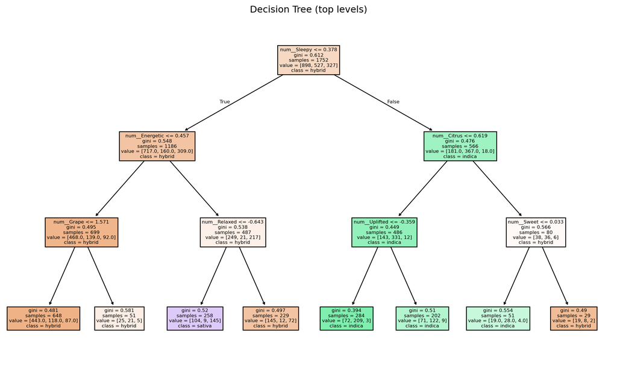

```python
p2 = df.dropna()

# Creating new target and explanatory variables
X = p2.drop(columns=['Type'])
y = p2['Type']

Xt, Xv, yt, yv = train_test_split(X, y, test_size=0.2, random_state=42, stratify=y)

# Creating a pipeline for DTC
tree = Pipeline([
    ('preprocess', ct),
    ('model', DecisionTreeClassifier())
])

tree_grid = {
    'model__max_depth': [3,5,7,9,11],
    'model__min_samples_split': [2,3,4],
    'model__criterion': ['gini', 'entropy']
}

grid_tree = GridSearchCV(tree, tree_grid, cv=5, scoring='accuracy')
grid_tree.fit(Xt, yt)
y_pred = grid_tree.predict(Xv)
print('tree accuracy', accuracy_score(yv, y_pred))
print('classification report', classification_report(yv, y_pred))

# plot the tuned tree

# getting tuned decision tree
best_tree = grid_tree.best_estimator_

# extracting importance scores
imp = best_tree.named_steps['model'].feature_importances_

# extracting feature names after preprocessing
feat = best_tree.named_steps['preprocess'].get_feature_names_out()

plt.figure(figsize=(14,8))

plot_tree(
    best_tree.named_steps['model'],
    feature_names=feat,
    class_names=best_tree.named_steps['model'].classes_,
    filled=True,
    max_depth=3
)

plt.title('Decision Tree (top levels)')
```

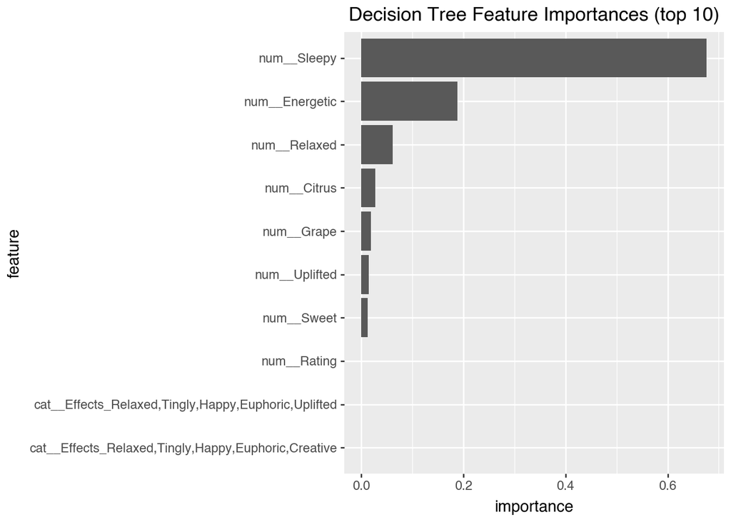

```python
# Building a dataframe of top important feature for plotting
formatted = (
    pd.DataFrame({'feature': feat, 'importance': imp})
                .sort_values('importance', ascending=False)
                .head(10) # Limiting to 15 entries
)

# Plotting
(
    ggplot(formatted, aes(x='reorder(feature, importance)', y='importance'))
    + geom_col()
    + coord_flip()
    + labs(
        x='feature',
        y='importance',
        title='Decision Tree Feature Importances (top 10)'
    )
)
```

Q2 Repeat the analyses from Part One for LDA, QDA, and KNN.

```python
# For LDA
# Creating a pipeline for Linear Discriminatory Analysis
LDApipe = Pipeline([
    ('preprocess', ct),
    ('model', LinearDiscriminantAnalysis())
])

# Defining grid for the solver and shrinkage
# Since SVD doesn't support shrinkage, I used a list of dicts
LDAparams = [
    {'model__solver': ['svd']},
    {'model__solver': ['lsqr', 'eigen'], 'model__shrinkage': [0.1, 0.5, 0.9]}
]

# Running Grid Search
LDAgrid = GridSearchCV(LDApipe, LDAparams, cv=5, scoring='accuracy')
LDAgrid.fit(Xt, yt)

print(f'Best CV accuracy: {LDAgrid.best_score_}')
print(f'Best Params: {LDAgrid.best_params_}')


# Generating predictions on the validation set using the best model
best_lda = LDAgrid.best_estimator_
y_pred = best_lda.predict(Xv)

# specifying class order for rows/columns
labels = ['indica', 'sativa']

# Designing a confusion matrix
cm = confusion_matrix(yv, y_pred, labels=labels)
cm_df = pd.DataFrame(cm, index=[f"Actual {lbl}" for lbl in labels], # appending row labels
                    columns=[f"Predicted {lbl}" for lbl in labels]) # appending column labels
print(cm_df)
```

```
Best CV accuracy: 0.6301408221408222
Best Params: {'model__shrinkage': 0.5, 'model__solver': 'lsqr'}
               Predicted indica  Predicted sativa
Actual indica                91                 4
Actual sativa                 9                35
```

cross validated accuracy: 0.6301

```python
# Creating a pipeline for Quadratic Discriminatory Analysis
QDApipe = Pipeline([
    ('preprocess', ct),
    ('pca', PCA(n_components=0.95, random_state=42)), # reduces the collinearity
    ('model', QuadraticDiscriminantAnalysis())
])

# Tuning the regularization params
qda_params = {
    'model__reg_param': [0.0, 0.1, 0.3, 0.5, 0.7, 0.9, 1.0]
}

# Running Grid Search
qdaGrid = GridSearchCV(QDApipe, qda_params, cv=5, scoring='accuracy')
# Fitting the pipe on the training data
qdaGrid.fit(Xt, yt)

print(f'Best CV accuracy: {qdaGrid.best_score_}')
print(f'Best Params: {qdaGrid.best_params_}')

# Generating predictions on the validation set using best model
best_qda = qdaGrid.best_estimator_
y_pred = best_qda.predict(Xv)

# specifying class order for rows/columns
labels = ['indica', 'sativa']

# Designing a confusion matrix
cm = confusion_matrix(yv, y_pred, labels=labels)
cm_df = pd.DataFrame(cm, index=[f"Actual {lbl}" for lbl in labels], # appending row labels
                    columns=[f"Predicted {lbl}" for lbl in labels]) # appending column labels
print(cm_df)
```

```
Best CV accuracy: 0.6289898249898249
Best Params: {'model__reg_param': 1.0}
               Predicted indica  Predicted sativa
Actual indica                89                 3
Actual sativa                 7                33
```

cross validated accuracy: 0.63

```python
# For kNN
knnpipe = Pipeline([
    ('preprocess', ct),
    ('model', KNeighborsClassifier())
])

knnpipe.fit(Xt,yt)

knn_grid = {
    'model__n_neighbors': [3,5,7,9],
    'model__weights': ['uniform', 'distance']
}

gridknn = GridSearchCV(knnpipe, knn_grid, cv=5, scoring='accuracy')
gridknn.fit(Xt, yt)
y_pred = gridknn.predict(Xv)


print('best score:', gridknn.best_score_)
print('knn best params:', gridknn.best_params_)

labels = ['indica', 'sativa', 'hybrid']

cm = confusion_matrix(yv, y_pred, labels=labels)
cm_df = pd.DataFrame(cm, index=[f"Actual {lbl}" for lbl in labels], # appending row labels
                    columns=[f"Predicted {lbl}" for lbl in labels]) # appending column labels
print(cm_df)
```

```
best score: 0.569054945054945
knn best params: {'model__n_neighbors': 9, 'model__weights': 'uniform'}
               Predicted indica  Predicted sativa  Predicted hybrid
Actual indica                62                 0                70
Actual sativa                11                11                60
Actual hybrid                44                11               170
```

Q3 Were your metrics better or worse than in Part One? Why? Which categories were most likely to get mixed up, according to the confusion matrices? Why?

Part Three: Multiclass from Binary Consider two models designed for binary classification: SVC and Logistic Regression.

Q1 Fit and report metrics for OvR versions of the models. That is, for each of the two model types, create three models:

Indica vs. Not Indica

```python
# For SVC
base = df.dropna()
tmp = base.copy()
tmp['indica'] = (tmp['Type'] == 'indica')

X = tmp.drop(columns=['Type', 'indica'])
y = tmp['indica']

Xt, Xv, yt, yv = train_test_split(X, y, test_size=0.2, random_state=42, stratify=y)

# Getting numeric and categorical variables
num = X.select_dtypes(include=['number']).columns
cat = X.select_dtypes(exclude=['number']).columns

# Defining columnTransformer for preprocessing steps
ct = ColumnTransformer(
    transformers=[
    ('num', StandardScaler(), num),
    ('cat', OneHotEncoder(handle_unknown='ignore', sparse_output=False), cat)
])

SVCpipe = Pipeline([
    ('preprocess', ct),
    ('model', SVC())
])

# Fitting the pipe on the training data
SVCpipe.fit(Xt, yt)

# Finding cross-validated accuracy
print(np.mean(cross_val_score(SVCpipe, X, y, cv=5, scoring='accuracy')))

# Generating predictions on the validation set
y_pred = SVCpipe.predict(Xv)

# specifying class order for rows/columns
labels = [False, True]

# Designing a confusion matrix
cm = confusion_matrix(yv, y_pred, labels=labels)
cm_df = pd.DataFrame(cm, index=[f"Actual {lbl}" for lbl in labels], # appending row labels
                    columns=[f"Predicted {lbl}" for lbl in labels]) # appending column labels
print(cm_df)
```

```
0.7781945267887791
              Predicted False  Predicted True
Actual False              277              30
Actual True                56              76
```

cv score: 0.7781945267887791

```python
# For Logistic Regression
logit = Pipeline([
    ('preprocess', ct),
    ('model', LogisticRegression())
])

# Fitting the pipe on the training data
logit.fit(Xt, yt)

# Finding cross-validated accuracy
print(np.mean(cross_val_score(logit, X, y, cv=5, scoring='accuracy')))

# Generating predictions on the validation set
y_pred = logit.predict(Xv)

# specifying class order for rows/columns
labels = [False, True]

# Designing a confusion matrix
cm = confusion_matrix(yv, y_pred, labels=labels)
cm_df = pd.DataFrame(cm, index=[f"Actual {lbl}" for lbl in labels], # appending row labels
                    columns=[f"Predicted {lbl}" for lbl in labels]) # appending column labels
print(cm_df)
```

```
0.7864085041761579
              Predicted False  Predicted True
Actual False              275              32
Actual True                47              85
```

cv score: 0.7864085041761579

Sativa vs. Not Sativa

```python
# For SVC
tmp = base.copy()
tmp['sativa'] = (tmp['Type'] == 'sativa')

X = tmp.drop(columns=['Type', 'sativa'])
y = tmp['sativa']

Xt, Xv, yt, yv = train_test_split(X, y, test_size=0.2, random_state=42, stratify=y)

# Getting numeric and categorical variables
num = X.select_dtypes(include=['number']).columns
cat = X.select_dtypes(exclude=['number']).columns

# Defining columnTransformer for preprocessing steps
ct = ColumnTransformer(
    transformers=[
    ('num', StandardScaler(), num),
    ('cat', OneHotEncoder(handle_unknown='ignore', sparse_output=False), cat)
])

SVCpipe = Pipeline([
    ('preprocess', ct),
    ('model', SVC())
])

# Fitting the pipe on the training data
SVCpipe.fit(Xt, yt)

# Finding cross-validated accuracy
print(np.mean(cross_val_score(SVCpipe, X, y, cv=5, scoring='accuracy')))

# Generating predictions on the validation set
y_pred = SVCpipe.predict(Xv)

# specifying class order for rows/columns
labels = [False, True]

# Designing a confusion matrix
cm = confusion_matrix(yv, y_pred, labels=labels)
cm_df = pd.DataFrame(cm, index=[f"Actual {lbl}" for lbl in labels], # appending row labels
                    columns=[f"Predicted {lbl}" for lbl in labels]) # appending column labels
print(cm_df)
```

```
0.8188057124431823
              Predicted False  Predicted True
Actual False              343              14
Actual True                69              13
```

CV scores: 0.8188057124431823

```python
# For Logistic Regression
logit = Pipeline([
    ('preprocess', ct),
    ('model', LogisticRegression())
])

# Fitting the pipe on the training data
logit.fit(Xt, yt)

# Finding cross-validated accuracy
print(np.mean(cross_val_score(logit, X, y, cv=5, scoring='accuracy')))

# Generating predictions on the validation set
y_pred = logit.predict(Xv)

# specifying class order for rows/columns
labels = [False, True]

# Designing a confusion matrix
cm = confusion_matrix(yv, y_pred, labels=labels)
cm_df = pd.DataFrame(cm, index=[f"Actual {lbl}" for lbl in labels], # appending row labels
                    columns=[f"Predicted {lbl}" for lbl in labels]) # appending column labels
print(cm_df)
```

```
0.825653987372713
              Predicted False  Predicted True
Actual False              327              30
Actual True                62              20
```

CV scores: 0.825653987372713

Hybrid vs. Not Hybrid

```python
# For SVC
tmp = base.copy()
tmp['hybrid'] = (tmp['Type'] == 'hybrid')

X = tmp.drop(columns=['Type', 'hybrid'])
y = tmp['hybrid']
Xt, Xv, yt, yv = train_test_split(X, y, test_size=0.2, random_state=42, stratify=y)

# Getting numeric and categorical variables
num = X.select_dtypes(include=['number']).columns
cat = X.select_dtypes(exclude=['number']).columns

# Defining columnTransformer for preprocessing steps
ct = ColumnTransformer(
    transformers=[
    ('num', StandardScaler(), num),
    ('cat', OneHotEncoder(handle_unknown='ignore', sparse_output=False), cat)
])

SVCpipe = Pipeline([
    ('preprocess', ct),
    ('model', SVC())
])

# Fitting the pipe on the training data
SVCpipe.fit(Xt, yt)

# Finding cross-validated accuracy
print(np.mean(cross_val_score(SVCpipe, X, y, cv=5, scoring='accuracy')))

# Generating predictions on the validation set
y_pred = SVCpipe.predict(Xv)

# specifying class order for rows/columns
labels = [False, True]

# Designing a confusion matrix
cm = confusion_matrix(yv, y_pred, labels=labels)
cm_df = pd.DataFrame(cm, index=[f"Actual {lbl}" for lbl in labels], # appending row labels
                    columns=[f"Predicted {lbl}" for lbl in labels]) # appending column labels
print(cm_df)
```

```
0.6147834950749421
              Predicted False  Predicted True
Actual False              129              85
Actual True                74             151
```

cv scores: 0.6147834950749421

```python
# For Logistic Regression
logit = Pipeline([
    ('preprocess', ct),
    ('model', LogisticRegression())
])

# Fitting the pipe on the training data
logit.fit(Xt, yt)

# Finding cross-validated accuracy
print(np.mean(cross_val_score(logit, X, y, cv=5, scoring='accuracy')))

# Generating predictions on the validation set
y_pred = logit.predict(Xv)

# specifying class order for rows/columns
labels = [False, True]

# Designing a confusion matrix
cm = confusion_matrix(yv, y_pred, labels=labels)
cm_df = pd.DataFrame(cm, index=[f"Actual {lbl}" for lbl in labels], # appending row labels
                    columns=[f"Predicted {lbl}" for lbl in labels]) # appending column labels
print(cm_df)
```

```
0.6193538656764543
              Predicted False  Predicted True
Actual False              130              84
Actual True                55             170
```

CV scores: 0.6193538656764543

Q2 Which of the six models did the best job distinguishing the target category from the rest? Which did the worst? Does this make intuitive sense?

When assessing which of the 6 models did the best job distinguishing the target category from the rest, the Sativa vs. rest Logistic Regression (cv=.826), followed closely by Sativa SVC. The worst was Hybrid vs. rest (SVC = 0.615, logit = 0.619). Overall, this makes sense, as Sativa is the most distinct from the other two types, while Hybrid overlaps both Indica and Sativa, making it the hardest one vs rest separation.

Q3 Fit and report metrics for OvO versions of the models. That is, for each of the two model types, create three models:

Indica vs. Sativa

```python
# For Logistic Regression
ovo = df.dropna()
ovo = ovo.copy()
ovo = ovo[ovo['Type'].isin(['indica', 'sativa'])]

ovo['indica_v_sativa'] = ovo['Type'] == 'indica'

X = ovo.drop(columns=['Type', 'indica_v_sativa'])
y = ovo['indica_v_sativa']

Xt, Xv, yt, yv = train_test_split(X,y, test_size=0.2, random_state=42, stratify=y)

# Creating the Logistic Regression Pipeline

# Getting numeric and categorical variables
num = X.select_dtypes(include=['number']).columns
cat = X.select_dtypes(exclude=['number']).columns

ct = ColumnTransformer([
      ('num', StandardScaler(), num),
      ('cat', OneHotEncoder(handle_unknown='ignore', sparse_output=False), cat)
])

logit = Pipeline([
    ('preprocess', ct),
    ('model', LogisticRegression())
])

# Fitting the OvO model on the training dataset
logit.fit(Xt, yt)

# Finding cross-validated accuracy
print(np.mean(cross_val_score(logit, X, y, cv=5, scoring='accuracy')))

# Generating predictions on the validation set
y_pred = logit.predict(Xv)

# specifying class order for rows/columns
labels = [False, True]

# Designing a confusion matrix
cm = confusion_matrix(yv, y_pred, labels=labels)
cm_df = pd.DataFrame(cm, index=[f"Actual {lbl}" for lbl in labels], # appending row labels
                    columns=[f"Predicted {lbl}" for lbl in labels]) # appending column labels
print(cm_df)
```

```
0.8539423456627617
              Predicted False  Predicted True
Actual False               69              13
Actual True                11             121
```

Cross validated accuracy score: 0.8539423456627617

```python
# For Logistic Regression
ovo = df.dropna()
ovo = ovo.copy()
ovo = ovo[ovo['Type'].isin(['indica', 'sativa'])]

ovo['indica_v_sativa'] = ovo['Type'] == 'indica'

X = ovo.drop(columns=['Type', 'indica_v_sativa'])
y = ovo['indica_v_sativa']

Xt, Xv, yt, yv = train_test_split(X,y, test_size=0.2, random_state=42, stratify=y)

# Creating the SVM Pipeline

svm = Pipeline([
    ('preprocess', ct),
    ('model', SVC())
])

# Fitting the OvO model on the training dataset
svm.fit(Xt, yt)

# Finding cross-validated accuracy
print(np.mean(cross_val_score(svm, X, y, cv=5, scoring='accuracy')))

# Generating predictions on the validation set
y_pred = svm.predict(Xv)

# specifying class order for rows/columns
labels = [False, True]

# Designing a confusion matrix
cm = confusion_matrix(yv, y_pred, labels=labels)
cm_df = pd.DataFrame(cm, index=[f"Actual {lbl}" for lbl in labels], # appending row labels
                    columns=[f"Predicted {lbl}" for lbl in labels]) # appending column labels
print(cm_df)
```

```
0.8408757843008206
              Predicted False  Predicted True
Actual False               67              15
Actual True                12             120
```

Cross validation accuracy score: 0.8408757843008206

Indica vs. Hybrid

```python
# For Logistic Regression
ovo = df.dropna()
ovo = ovo.copy()
ovo = ovo[ovo['Type'].isin(['indica', 'hybrid'])]

ovo['indica_v_hybrid'] = ovo['Type'] == 'indica'

X = ovo.drop(columns=['Type', 'indica_v_hybrid'])
y = ovo['indica_v_hybrid']

Xt, Xv, yt, yv = train_test_split(X,y, test_size=0.2, random_state=42, stratify=y)

# Creating the Logistic Regression Pipeline

# Getting numeric and categorical variables
num = X.select_dtypes(include=['number']).columns
cat = X.select_dtypes(exclude=['number']).columns

ct = ColumnTransformer([
      ('num', StandardScaler(), num),
      ('cat', OneHotEncoder(handle_unknown='ignore', sparse_output=False), cat)
])

logit = Pipeline([
    ('preprocess', ct),
    ('model', LogisticRegression())
])

# Fitting the OvO model on the training dataset
logit.fit(Xt, yt)

# Finding cross-validated accuracy
print(np.mean(cross_val_score(logit, X, y, cv=5, scoring='accuracy')))

# Generating predictions on the validation set
y_pred = logit.predict(Xv)

# specifying class order for rows/columns
labels = [False, True]

# Designing a confusion matrix
cm = confusion_matrix(yv, y_pred, labels=labels)
cm_df = pd.DataFrame(cm, index=[f"Actual {lbl}" for lbl in labels], # appending row labels
                    columns=[f"Predicted {lbl}" for lbl in labels]) # appending column labels
print(cm_df)
```

```
0.7401882101155068
              Predicted False  Predicted True
Actual False              179              46
Actual True                53              79
```

Cross validated accuracy score: 0.7401882101155068

```python
ovo = df.dropna()
ovo = ovo.copy()
ovo = ovo[ovo['Type'].isin(['indica', 'hybrid'])]

ovo['indica_v_hybrid'] = ovo['Type'] == 'indica'

X = ovo.drop(columns=['Type', 'indica_v_hybrid'])
y = ovo['indica_v_hybrid']

Xt, Xv, yt, yv = train_test_split(X,y, test_size=0.2, random_state=42, stratify=y)

# Creating the SVM Pipeline

svm = Pipeline([
    ('preprocess', ct),
    ('model', SVC())
])

# Fitting the OvO model on the training dataset
svm.fit(Xt, yt)

# Finding cross-validated accuracy
print(np.mean(cross_val_score(svm, X, y, cv=5, scoring='accuracy')))

# Generating predictions on the validation set
y_pred = svm.predict(Xv)

# specifying class order for rows/columns
labels = [False, True]

# Designing a confusion matrix
cm = confusion_matrix(yv, y_pred, labels=labels)
cm_df = pd.DataFrame(cm, index=[f"Actual {lbl}" for lbl in labels], # appending row labels
                    columns=[f"Predicted {lbl}" for lbl in labels]) # appending column labels
print(cm_df)
```

```
0.7317801277814496
              Predicted False  Predicted True
Actual False              177              48
Actual True                49              83
```

Cross validation accuracy score: 0.7317801277814496

Hybrid vs. Sativa

```python
# For Logistic Regression
ovo = df.dropna()
ovo = ovo.copy()
ovo = ovo[ovo['Type'].isin(['hybrid', 'sativa'])]

ovo['hybrid_v_sativa'] = ovo['Type'] == 'hybrid'

X = ovo.drop(columns=['Type', 'hybrid_v_sativa'])
y = ovo['hybrid_v_sativa']

Xt, Xv, yt, yv = train_test_split(X,y, test_size=0.2, random_state=42, stratify=y)

# Creating the Logistic Regression Pipeline

# Getting numeric and categorical variables
num = X.select_dtypes(include=['number']).columns
cat = X.select_dtypes(exclude=['number']).columns

ct = ColumnTransformer([
      ('num', StandardScaler(), num),
      ('cat', OneHotEncoder(handle_unknown='ignore', sparse_output=False), cat)
])

logit = Pipeline([
    ('preprocess', ct),
    ('model', LogisticRegression())
])

# Fitting the OvO model on the training dataset
logit.fit(Xt, yt)

# Finding cross-validated accuracy
print(np.mean(cross_val_score(logit, X, y, cv=5, scoring='accuracy')))

# Generating predictions on the validation set
y_pred = logit.predict(Xv)

# specifying class order for rows/columns
labels = [False, True]

# Designing a confusion matrix
cm = confusion_matrix(yv, y_pred, labels=labels)
cm_df = pd.DataFrame(cm, index=[f"Actual {lbl}" for lbl in labels], # appending row labels
                    columns=[f"Predicted {lbl}" for lbl in labels]) # appending column labels
print(cm_df)
```

```
0.7506482723382513
              Predicted False  Predicted True
Actual False               31              51
Actual True                22             203
```

Cross validated accuracy score: 0.7506482723382513

```python
ovo = df.dropna()
ovo = ovo.copy()
ovo = ovo[ovo['Type'].isin(['hybrid', 'sativa'])]

ovo['hybrid_v_sativa'] = ovo['Type'] == 'hybrid'

X = ovo.drop(columns=['Type', 'hybrid_v_sativa'])
y = ovo['hybrid_v_sativa']

Xt, Xv, yt, yv = train_test_split(X,y, test_size=0.2, random_state=42, stratify=y)

# Creating the SVM Pipeline

svm = Pipeline([
    ('preprocess', ct),
    ('model', SVC())
])

# Fitting the OvO model on the training dataset
svm.fit(Xt, yt)

# Finding cross-validated accuracy
print(np.mean(cross_val_score(svm, X, y, cv=5, scoring='accuracy')))

# Generating predictions on the validation set
y_pred = svm.predict(Xv)

# specifying class order for rows/columns
labels = [False, True]

# Designing a confusion matrix
cm = confusion_matrix(yv, y_pred, labels=labels)
cm_df = pd.DataFrame(cm, index=[f"Actual {lbl}" for lbl in labels], # appending row labels
                    columns=[f"Predicted {lbl}" for lbl in labels]) # appending column labels
print(cm_df)
```

```
0.7336739690447297
              Predicted False  Predicted True
Actual False               13              69
Actual True                 6             219
```

Cross validation accuracy score: 0.7336739690447297

Q4 Which of the six models did the best job distinguishing at differentiating the two groups? Which did the worst? Does this make intuitive sense?

The sativa v. indica logistic regression model performed the best in terms of cross validated score, with an accuracy of ~0.85. The model that performed the worst was the indica v. hybrid SVM model, with a cross validated accuracy score of ~0.73. Intuitively, this makes sense, as sativa versus indica strains separate more cleanly, but hybrids overlap the types, making a harder boundary for the SVM model.

Q5 Suppose you had simply input the full data, with three classes, into the LogisticRegression function. Would this have automatically taken an “OvO” approach or an “OvR” approach?

For logistic regression, by default the (multi_class=‘auto’ with a multinomial-capable solver like lbfgs), it fits a multinomial model, not OvO. If you pick a solver that can’t do multinomial, it falls back to one-versus-rest.

What about for SVC? For multi-class inputs, it always uses one-vs-one.

Note: You do not actually have to run code here - you only need to look at sklearn’s documentation to see how these functions handle multiclass input.